# CIND 123 Summer 2019 - Assignment #3

Andy Lee 500163559

Use RStudio for this assignment. Edit the file `A3-S19-Q` and insert your R code where wherever you see the string “INSERT YOUR ANSWER HERE”

## Sample Question and Solution

Use `seq()` to create the vector $(2,4,6,\ldots,20)$.

```r
#Insert your code here.
seq(2,20,by = 2)
```

```
##  [1]  2  4  6  8 10 12 14 16 18 20
```

##Question 1

Install the `marketing` dataset on your computer using the command `install.packages("datarium")`. Then load the `datarium` package into your session using the following command. Understand the dataset by using `??marketing` command.

```r
library(datarium)
attach(marketing)
```

1. Plot the advertising budget of `Youtube` against `Sales`. Comment on their relationship. Hint: You may use the `ggplot()` function from `ggplot2` package.

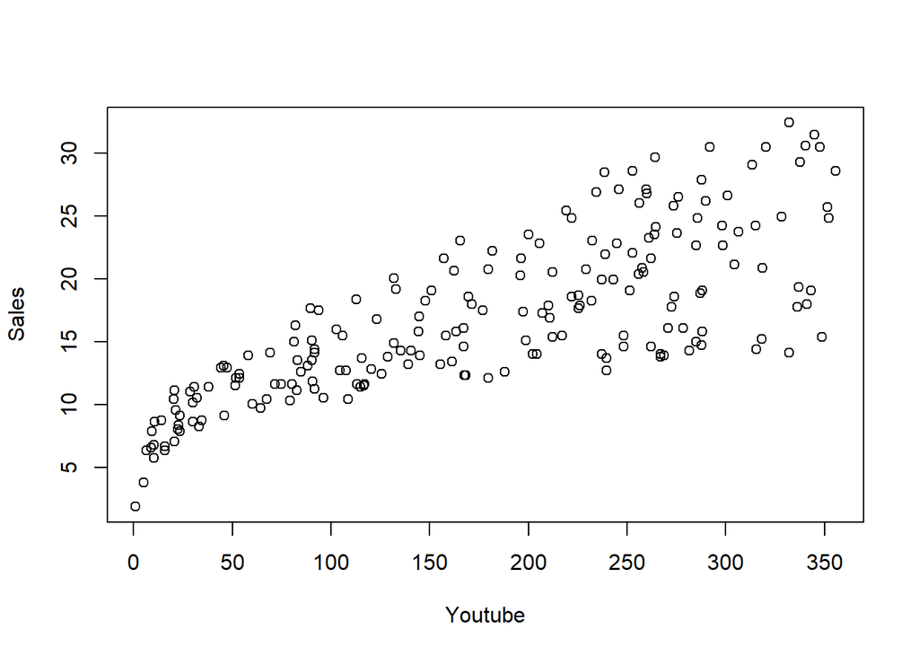

```r
mkt <- marketing
plot(x=mkt$youtube, y=mkt$sales, xlab = "Youtube", ylab = "Sales")
```

```r
# there appears to a somewhat-strong positive correlation between Youtube and Sales. correlation seems to be tighter for low values of Youtube while the variance appears larger for higher values of Youtube
```

2. Find the correlation between advertising budget of `Youtube` against `Sales`. Comment on the output. Does it match your intuition from part (a).

```r
cor(mkt$youtube,mkt$sales)
```

```
## [1] 0.7822244
```

```r
# correlation is 0.7822244, somewhat strong since its closer to 1.
```

3. Plot the `Sales` as a function of `Youtube` variable using a scatterplot, and graph the least-square line on the same plot.

```r
model_yt <- lm(sales~youtube, data = mkt)
summary(model_yt)
```

```
##
## Call:
## lm(formula = sales ~ youtube, data = mkt)
##
## Residuals:
##      Min       1Q   Median       3Q      Max
## -10.0632  -2.3454  -0.2295   2.4805   8.6548
##
## Coefficients:
##             Estimate Std. Error t value Pr(>|t|)
## (Intercept) 8.439112   0.549412   15.36   <2e-16 ***
## youtube     0.047537   0.002691   17.67   <2e-16 ***
## ---
## Signif. codes:  0 '***' 0.001 '**' 0.01 '*' 0.05 '.' 0.1 ' ' 1
##
## Residual standard error: 3.91 on 198 degrees of freedom
## Multiple R-squared:  0.6119, Adjusted R-squared:  0.6099
## F-statistic: 312.1 on 1 and 198 DF,  p-value: < 2.2e-16
```

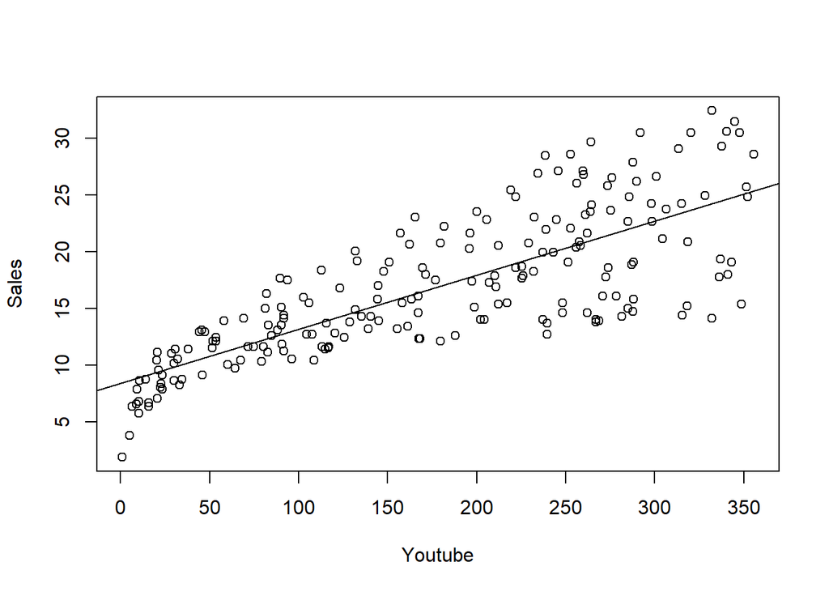

```r
plot(x=mkt$youtube, y=mkt$sales, xlab = "Youtube", ylab = "Sales")
abline(model_yt)
```

4. Use the regression line to predict the `Sales` amount when `Youtube` budget is `$69K`.

```r
new.amount <- data.frame(youtube = c(69))
predict(model_yt, newdata =  new.amount)
```

```
##        1
## 11.71914
```

5. Use `youtube` and `facebook` variables to build a linear regression model to predict `sales` Display a summary of your model indicating Residuals, Coefficients, …, etc. What conclusion can you draw from this summary?

```r
model_ytfb <- lm(sales~youtube+facebook, data = mkt)
summary(model_ytfb)
```

```
##
## Call:
## lm(formula = sales ~ youtube + facebook, data = mkt)
##
## Residuals:
##      Min       1Q   Median       3Q      Max
## -10.5572  -1.0502   0.2906   1.4049   3.3994
##
## Coefficients:
##             Estimate Std. Error t value Pr(>|t|)
## (Intercept)  3.50532    0.35339   9.919   <2e-16 ***
## youtube      0.04575    0.00139  32.909   <2e-16 ***
## facebook     0.18799    0.00804  23.382   <2e-16 ***
## ---
## Signif. codes:  0 '***' 0.001 '**' 0.01 '*' 0.05 '.' 0.1 ' ' 1
##
## Residual standard error: 2.018 on 197 degrees of freedom
## Multiple R-squared:  0.8972, Adjusted R-squared:  0.8962
## F-statistic: 859.6 on 2 and 197 DF,  p-value: < 2.2e-16
```

6. Use the regression line to predict the `Sales` amount when `youtube` budget is `$69K` and `facebook` is `$39.36K`.

```r
new.amount2 <- data.frame(youtube = c(69), facebook = c(39.36))
predict(model_ytfb,newdata = new.amount2)
```

```
##        1
## 14.06185
```

7. What is the difference between the output in (f) and the output in (d)

```r
# (f) values is higher than (d), (f) values include more information as it takes into account youtube and facebook's effect on sales
```

8. Display the correlation matrix of the variables: `youtube`, `facebook`, `newspaper` and `sales`. What conclusion can you draw?

```r
cor(mkt)
```

```
##              youtube   facebook  newspaper     sales
## youtube   1.00000000 0.05480866 0.05664787 0.7822244
## facebook  0.05480866 1.00000000 0.35410375 0.5762226
## newspaper 0.05664787 0.35410375 1.00000000 0.2282990
## sales     0.78222442 0.57622257 0.22829903 1.0000000
```

1. In your opinion, which statistical test should be used to discuss the relationship between `youtube` and `sales`? Hint: Review the differnce between Pearson and Spearman tests.

```r
cor(mkt$youtube,mkt$sales,method = 'pearson')
```

```
## [1] 0.7822244
```

```r
cor(mkt$youtube,mkt$sales,method = 'spearman')
```

```
## [1] 0.8006144
```

```r
# pearson would be more accurate as its better at evaluating continuous values, which sales, youtube, facebook, newspaper all are. Compare to spearman which is suitable for rank-ordered ordinal.
```

## Question 2

This question makes use of package “ISwR”. Please load `airquality` dataset as following:

```r
#install.packages("ISwR")
library(ISwR)
data(airquality)
str(airquality)
```

```
## 'data.frame':    153 obs. of  6 variables:
##  $ Ozone  : int  41 36 12 18 NA 28 23 19 8 NA ...
##  $ Solar.R: int  190 118 149 313 NA NA 299 99 19 194 ...
##  $ Wind   : num  7.4 8 12.6 11.5 14.3 14.9 8.6 13.8 20.1 8.6 ...
##  $ Temp   : int  67 72 74 62 56 66 65 59 61 69 ...
##  $ Month  : int  5 5 5 5 5 5 5 5 5 5 ...
##  $ Day    : int  1 2 3 4 5 6 7 8 9 10 ...
```

1. Use a histogram to assess the normality of the `Ozone` variable, then explain why it does not appear normally distributed.

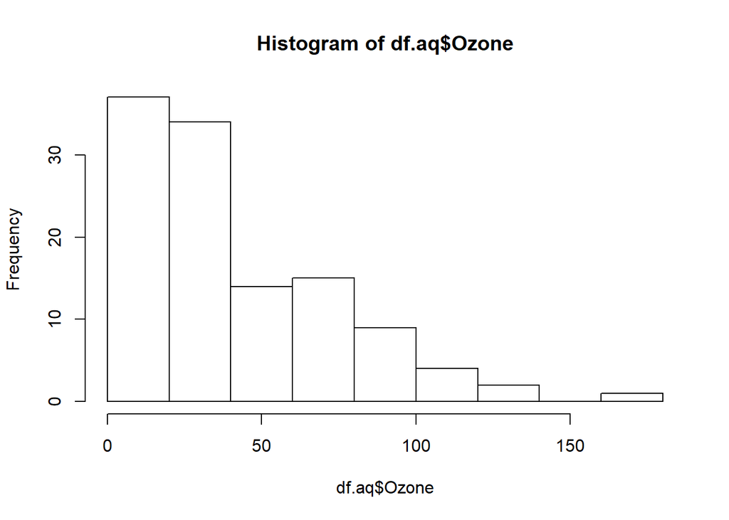

```r
df.aq <- airquality
hist(df.aq$Ozone)
```

```r
# because ozone measurements are dependent on other factors and not an independent variable. the ozone variable would not be symmetric in nature around its mean, a property of the normal distribution. while there may be instances of high ozone, there are no negative values of ozone.
```

2. Create a boxplot that shows the distribution of `Ozone` in each month. Use different colors for each month.

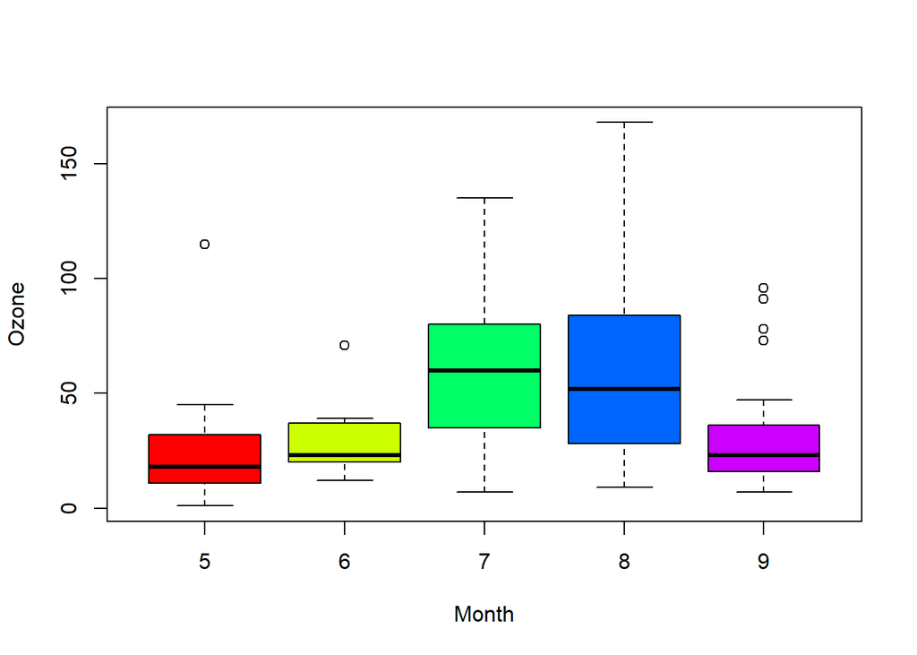

```r
boxplot(Ozone~Month,data = df.aq, col=rainbow(length(unique(df.aq$Month))))
```

## Question 3

$\pi$ appears in the formula for the standard normal distribution, the most important probability distribution in statistics. Why not give it a try to calculate $\pi$ using statistics! In fact, you’ll use a simulation technique called the *Monte Carlo Method*.

Recall that the area of a circle of radius $r$ is $A = \pi r^2$. Therefore the area of a circle of radius 1, aka a *unit circle*, is $\pi$. You’ll compute an approximation to the area of this circle using the Monte Carlo Method.

1. The Monte Carlo Method uses random numbers to simulate some process. Here the process is throwing darts at a square. Assume the darts are uniformly distributed over the square. Imagine a unit circle enclosed by a square whose sides are of length 2. Set an R variable `area.square` to be the area of a square whose sides are of length 2.

```r
square.length = 2
area.square = square.length^2
```

2. The points of the square can be given x-y coordinates. Let both x and y range from -1 to +1 so that the square is centred on the origin of the coordinate system. Throw some darts at the square by generating random numeric vectors x and y, each of length `N = 10,000`. Set R variables `x` and `y` each to be uniformly distributed random numbers in the range -1 to +1. (hint: runif() generates random number for the uniform distribution)

```r
N = 10000
df.cord <- data.frame(x = runif(N, -1, 1), y = runif(N, -1, 1))
```

3. Now count how many darts landed inside the unit circle. Recall that a point is inside the unit circle when $x^2 + y^2 < 1$. Save the result of successful hits in a variable named hit. (hint: a for loop over the length of x and y is one option to reach hit)

```r
hit <- sum((df.cord$x^2 + df.cord$y^2) <= 1)
```

4. The probability that a dart hits inside the circle is proportional to the ratio of the area of the circle to the area of the square. Use this fact to calculate an approximation to $\pi$ and print the result

```r
(hit/N) * area.square
```

```
## [1] 3.152
```

You got the first estimate for `pi` $\pi$, congratulations you have completed the first run of the Monte Carlo simulation. If there is further interest put all the above logic in a function, and call it 50 times store the results in a vector called pi then take the mean of pi vector.

```r
mcsim <- function() {
  square.length = 2
  area.square = square.length^2
  N = 1000000
  df.cord <- data.frame(x = runif(N, -1, 1), y = runif(N, -1, 1))
  hit <- sum((df.cord$x^2 + df.cord$y^2) <= 1)
  (hit/N) * area.square
}


pi <- replicate(50, mcsim())
mean(pi)
```

```
## [1] 3.141897
```